# Week 3: Decision Trees & Regression Trees

Xuan Pham

2018-11-06

We have looked at three classification models in this course so far: 1) knn, 2) Naive Bayes, and 3) logistic regression. We have also examined numeric prediction using multiple linear regression model. We will introduce trees models this week. Tree models are mostly employed for classification prediction, and, hence, are called **decision trees**. Yet, tree models are also flexible enough to be used on numeric predictions as well; these models are called **regression trees**. We will discuss both decision and regression trees in this lesson.

# Getting Started

The packages you will need for this week are **rpart**, **rpart.plot**, **forecast**, and **caret**.

## A Simple Example: Will a Customer Buy a Computer?

The following AllElectronics dataset and example are taken from the third edition **Applied Data Mining: Concepts and Techniques** by Han, Kamber, and Pei (2012, Chapter 8).

```r
ages <- c("Under30","Under30","30to40","Over40","Over40","Over40","30to40","Under30","Under30", "Over40", "Under30","30to40","30to40", "Over40")
income <-c("high","high","high","medium","low","low","low","medium","low", "medium", "medium", "medium","high","medium")
student <- c("no","no","no", "no","yes","yes","yes","no","yes","yes","yes", "no","yes", "no")
credit_rating <- c("fair","excellent","fair","fair","fair","excellent","excellent","fair","fair","fair","excellent","excellent","fair","excellent")
buys_computer<- c("no","no","yes","yes","yes","no","yes","no","yes","yes","yes","yes","yes", "no")
ages<-as.factor(ages)
income <-as.factor(income)
student<- as.factor(student)
credit_rating<-as.factor(credit_rating)
buys_computer<- as.factor(buys_computer)
cust_data <-data.frame(ages,income,student,credit_rating,buys_computer)

cust_data
```

```
##       ages income student credit_rating buys_computer
## 1  Under30   high      no          fair            no
## 2  Under30   high      no     excellent            no
## 3   30to40   high      no          fair           yes
## 4   Over40 medium      no          fair           yes
## 5   Over40    low     yes          fair           yes
## 6   Over40    low     yes     excellent            no
## 7   30to40    low     yes     excellent           yes
## 8  Under30 medium      no          fair            no
## 9  Under30    low     yes          fair           yes
## 10  Over40 medium     yes          fair           yes
## 11 Under30 medium     yes     excellent           yes
## 12  30to40 medium      no     excellent           yes
## 13  30to40   high     yes          fair           yes
## 14  Over40 medium      no     excellent            no
```

## Recursive Partitioning

Decision trees are grown using a concept called *recursive partitioning**, or** top down, greedy, divide, and conquer approach**. Here is an overview of how recursive partitioning works:

1. Choose the attribute that is most predictive of the target variable.
2. Observations in the training set are divided into groups of distinct values (i.e. categories). This form the first set of branches for the tree.
3. Continue to divide and conquer the nodes, choosing the attribute with the most prediction power each time until one of three conditions occur: a) all observations for a given node belong to the same class; b) no more remaining attriutes for further partitioning; or c) no observations are left to classify.

How do we determine the predictive power of an attribute at each splitting point? We can use a variety of heuristic or statistical measures. The most well-known decision tree algorithm is called **Classification and Regression Trees (CART)**, which is implemented in the **rpart** package in R. Hence, we will focus on the most popular statistical measures for selecting attributes in CART: **Information Gain (also called entropy measure)** and **Gini Impurity Index**.

## Statistical Measures of Impurity

### Information Gain

**Entropy Measure**

$entropy(T) = - \sum_{k=1}^m p_k log2(p_k)$

**Information Gain** $Gain(T,X) = Entropy(T) - Entropy(T, A)$

**Entropy** is a probabilistic measure of uncertainty or ignorance and **information** is a measure of the reduction in uncertainy. The entropy value can be as high as 1, when we have equal number of observations among the classes in the target variable. The lowest entropy value is 0, which means we have explained all the uncertainty in the training set.

#### Now Let’s See How We Can Use Information Gain to Pick the First Attribute to Create Our Decision Tree (i.e. Most Important Predictor)

In our training set, we have **9** customers who purchased a computer and **5** would did not. With no decision tree model, we calculate a total entropy of 0.94 for the target variable (purchase/not purchase a computer).

```r
Ent_Buy<-((-9/14)*log2(9/14))-((5/14)*log2(5/14)) #entropy of the buy decision
print(Ent_Buy)
```

```
## [1] 0.940286
```

#### What about Income as a Predictor?

We can calculate the entropy value of each class in the Income predictor variable.

```r
Ent_Income_High<-((-2/4)*log2(2/4))-((2/4)*log2(2/4))
print(Ent_Income_High)
```

```
## [1] 1
```

```r
Ent_Income_Medium<-((-4/6)*log2(4/6))-((2/6)*log2(2/6))
print(Ent_Income_Medium)
```

```
## [1] 0.9182958
```

```r
Ent_Income_Low<-((-3/4)*log2(3/4))-((1/4)*log2(1/4))
print(Ent_Income_Low)
```

```
## [1] 0.8112781
```

The next step is to weigh each entropy value by the number of observations belonging to each class. The total entropy in the Income variable is 0.911.

```r
Ent_IncomeBuy <- (4/14)*Ent_Income_High + (6/14)*Ent_Income_Medium + (4/14)*Ent_Income_Low
print(Ent_IncomeBuy)
```

```
## [1] 0.9110634
```

If we use Income as a splitting variable, how much information have we gained with this predictor? A measly 0.029 (or 2.9%)!

```r
InfoGain_Income = Ent_Buy - Ent_IncomeBuy #information gained.
print(InfoGain_Income)
```

```
## [1] 0.02922257
```

Should we look at the other predictors?

#### What about Age?

```r
Ent_Age_Under30<-((-2/5)*log2(2/5))-((3/5)*log2(3/5))
print(Ent_Age_Under30)
```

```
## [1] 0.9709506
```

```r
Ent_Age_31_40<-((-4/4)*log2(4/4))
print(Ent_Age_31_40)
```

```
## [1] 0
```

```r
Ent_Age_Over40<-((-3/5)*log2(3/5))-((2/5)*log2(2/5))
print(Ent_Age_Over40)
```

```
## [1] 0.9709506
```

```r
Ent_AgeBuy <- (5/14)*Ent_Age_Under30 + (4/14)*Ent_Age_31_40 + (5/14)*Ent_Age_Over40
print(Ent_AgeBuy)
```

```
## [1] 0.6935361
```

```r
InfoGain_Age = Ent_Buy - Ent_AgeBuy #information gained.
print(InfoGain_Age)
```

```
## [1] 0.2467498
```

The total information gained if we use Age as a predictor is 0.247 or 24.7%. Not bad! Can we do better?

#### What about being a Student?

```r
Ent_Student_Yes<-((-6/7)*log2(6/7))-((1/7)*log2(1/7))
print(Ent_Student_Yes)
```

```
## [1] 0.5916728
```

```r
Ent_Student_No<-((-3/7)*log2(3/7))-((4/7)*log2(4/7))
print(Ent_Student_No)
```

```
## [1] 0.9852281
```

```r
Ent_StudentBuy <- (7/14)*Ent_Student_Yes + (7/14)*Ent_Student_No
print(Ent_StudentBuy)
```

```
## [1] 0.7884505
```

```r
InfoGain_Student = Ent_Buy - Ent_StudentBuy #information gained.
print(InfoGain_Student)
```

```
## [1] 0.1518355
```

The total information gained if we use Student status as a predictor is 0.152 or 15.2%.

#### What about Credit Rating Status?

```r
Ent_Credit_Excellent<-((-3/6)*log2(3/6))-((3/6)*log2(3/6))
print(Ent_Credit_Excellent)
```

```
## [1] 1
```

```r
Ent_Credit_Fair<-((-6/8)*log2(6/8))-((2/8)*log2(2/8))
print(Ent_Credit_Fair)
```

```
## [1] 0.8112781
```

```r
Ent_CreditBuy <- (6/14)*Ent_Credit_Excellent + (8/14)*Ent_Credit_Fair
print(Ent_CreditBuy)
```

```
## [1] 0.8921589
```

```r
InfoGain_Credit = Ent_Buy - Ent_CreditBuy #information gained.
print(InfoGain_Credit)
```

```
## [1] 0.04812703
```

The total information gained if we use Credit Rating status is 0.048 or 4.8%.

#### Implementing Recursive Partitioning

Now that we have all the information gains calculated, recursive partitioning says that the most “predictive” predictor is used as the first split for the decision tree model. The predictors in the order of importance (and used to split the decision tree model) are Age, Student, Credit, and Income.

```r
print(InfoGain_Age)
```

```
## [1] 0.2467498
```

```r
print(InfoGain_Student)
```

```
## [1] 0.1518355
```

```r
print(InfoGain_Credit)
```

```
## [1] 0.04812703
```

```r
print(InfoGain_Income)
```

```
## [1] 0.02922257
```

#### Problems with the Information Gain Measure

Information gain is biased towards choosing attributes with a large number of classes.

### Gini Index

**Gini index**

$Gini(T) = 1 - \sum_{k=1}^m p_k^2$

**Gini index** is a measure of impurity of the group of observations at each split. The highest Gini index depends on the number of classes in the target variable, and it can be calculated as $1- \frac 1 k$. The highest Gini index would occur if there are equal number of unclassified observations in all classes (k). The lowest Gini index is 0, which means all observations within each group belong to the same class.

*Please note that the **rpart** package uses the Gini Index as the default statistical measure for choosing predictors!*

#### Overall Gini Index for Target Variable (buy a computer).

```r
Gini_Buy<-1-((9/14)^2+(5/14)^2)
print(Gini_Buy)
```

```
## [1] 0.4591837
```

#### Gini Index of Income

```r
Gini_Income_High<-1-((2/4)^2+(2/4)^2)
Gini_Income_Medium<-1-((4/6)^2+(2/6)^2)
Gini_Income_Low<-1-((3/4)^2+(1/4)^2)

print(Gini_Income_High)
```

```
## [1] 0.5
```

```r
print(Gini_Income_Medium)
```

```
## [1] 0.4444444
```

```r
print(Gini_Income_Low)
```

```
## [1] 0.375
```

Now we have to weigh each Gini Index by the number of observations of each class in the target variable.

```r
Gini_Income <- (4/14)*Gini_Income_High + (6/14)*Gini_Income_Medium + (4/14)*Gini_Income_Low
print(Gini_Income)
```

```
## [1] 0.4404762
```

How much reduction in impurity if we use Income as a predictor? About 0.019.

```r
Gini_BuyIncome <- Gini_Buy - Gini_Income
print(Gini_BuyIncome)
```

```
## [1] 0.01870748
```

#### What About Age?

A reduction in impurity of 0.116,

```r
Gini_Age_Under30<-1-((2/5)^2+(3/5)^2)
Gini_Age_31_40<-1-((4/4)^2+(0/4)^2)
Gini_Age_Over_40<-1-((3/5)^2+(2/5)^2)

print(Gini_Age_Under30)
```

```
## [1] 0.48
```

```r
print(Gini_Age_31_40)
```

```
## [1] 0
```

```r
print(Gini_Age_Over_40)
```

```
## [1] 0.48
```

```r
Gini_Age <- (5/14)*Gini_Age_Under30 + (4/14)*Gini_Age_31_40 + (5/14)*Gini_Age_Over_40
print(Gini_Age)
```

```
## [1] 0.3428571
```

```r
Gini_BuyAge <- Gini_Buy - Gini_Age
print(Gini_BuyAge)
```

```
## [1] 0.1163265
```

#### What about Being a Student?

A reduction in impurity of 0.092.

```r
Gini_Student_Yes<-1-((6/7)^2+(1/7)^2)
Gini_Student_No<-1-((3/7)^2+(4/7)^2)

print(Gini_Student_Yes)
```

```
## [1] 0.244898
```

```r
print(Gini_Student_No)
```

```
## [1] 0.4897959
```

```r
Gini_Student <- (7/14)*Gini_Student_Yes + (7/14)*Gini_Student_No
print(Gini_Student)
```

```
## [1] 0.3673469
```

```r
Gini_BuyStudent <- Gini_Buy - Gini_Student
print (Gini_BuyStudent)
```

```
## [1] 0.09183673
```

#### What about Credit Rating?

```r
Gini_Credit_Excellent<-1-((3/6)^2+(3/6)^2)
Gini_Credit_Fair<-1-((6/8)^2+(2/8)^2)

print(Gini_Credit_Excellent)
```

```
## [1] 0.5
```

```r
print(Gini_Credit_Fair)
```

```
## [1] 0.375
```

```r
Gini_Credit <- (6/14)*Gini_Credit_Excellent + (8/14)*Gini_Credit_Fair
print(Gini_Credit)
```

```
## [1] 0.4285714
```

```r
Gini_BuyCredit <- Gini_Buy - Gini_Credit
```

#### Who’s the Winning Predictor?

Predictors in the order of predictive power: Age, Student status, Credit Rating, and Income.

```r
print(Gini_BuyAge)
```

```
## [1] 0.1163265
```

```r
print(Gini_BuyStudent)
```

```
## [1] 0.09183673
```

```r
print(Gini_BuyCredit)
```

```
## [1] 0.03061224
```

```r
print(Gini_BuyIncome)
```

```
## [1] 0.01870748
```

#### Problem with Gini Index

The Gini index is biased to multivalued attributes. The measure has difficulty when the number of classes is large. It also favors situations that result in equal-sized partitions and purity in both partitions.

## CART Implementation

So can we simplify all of the above calculations? Yes! We will use the Classification and Regression Tree (CART) implementation of decision tree models, which is in the **rpart** package.

```r
library(rpart)
library(rpart.plot)
set.seed(123)

# 80% train; 20% test
data_train <- cust_data[1:11,]
data_test  <- cust_data[11:14,]
prop.table(table(data_train$buys_computer))
```

```
##
##        no       yes
## 0.3636364 0.6363636
```

```r
prop.table(table(data_test$buys_computer))
```

```
##
##   no  yes
## 0.25 0.75
```

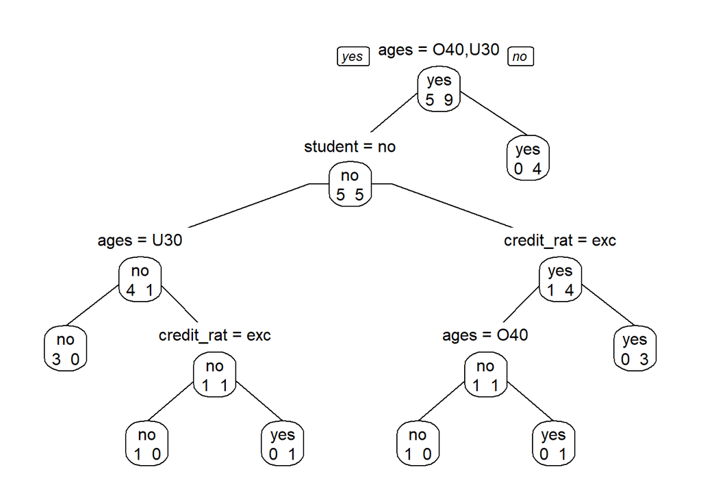

```r
data_rpart <- rpart(buys_computer ~ ., data=cust_data, method="class",
                    parms=list(split="information"),
                    control=rpart.control(minsplit = 1))

prp(data_rpart, type=1, extra=1, split.font=1, varlen = -10)
```

## Interpreting the Decision Tree Model

Starting from the root node, we see that there are **9 customers who purchased a computer** and **5 customers who did not purchase a computer**. The dominant class is **yes purchased a computer**.

First Split: *Is the customer Over40 or Under30?* If yes, go left. If no, go right. If you go right, notice that all 4 individuals purchased a computer. If you go left, you go to the next split.

Can you interpret the rest of this decision tree?

### What about Using the Gini Index?

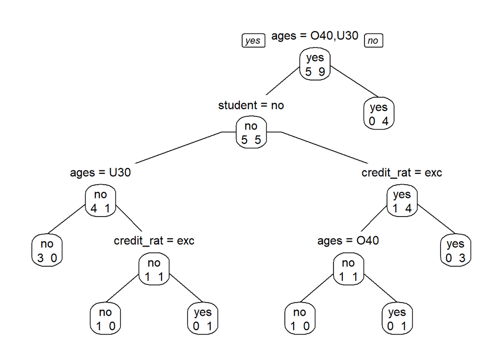

```r
data_rpart <- rpart(buys_computer ~ ., data=cust_data, method="class",
                    parms=list(split="gini"),
                    control=rpart.control(minsplit = 1))

prp(data_rpart, type=1, extra=1, split.font=1, varlen = -10)
```

## Let’s Talk About Overfitting

A problem with growing full tree models is that it is prone to **overfitting**. Overfitting occurs when we build a tree model that perfectly explains the training data but that’s all it does! The model is so specific to the training data that it performs terribly when we use it to classify unknown cases (i.e. test data). The way to overcome overfitting is to **prune** the fully grown tree.

### Cost complexity

The cost complexity of a tree is composed of two parts: **Residual Sum of Squares** and **penalty factor for the size of the tree**. For a tree **T** that has **L(k)** terminal nodes, the cost complexity is written as:

$Cost.Complexity(k) = RSS(k) + \alpha L(k)$

Where RSS(K) = residual sum of squares of tree k (i.e. a measure of misclassification error) $\alpha$ = penalty factor for a tree size ranging from 0 to 1. An $\alpha$ of 0 indicates a fully grown tree. An $\alpha$ of 1 indicates a tree with only the root node (no splits).

rpart calculates a similar measure to the Cost Complexity called the **complexity parameter (CP)**.

$CP = \alpha/RRS_1$

Where RRS_1 = residual sum of squares at the root node (i.e. before any split).

### rpart: Grow & Prune At the Same Time

The default stopping point for splitting a decision tree in rpart is CP = 0.01. If rpart reaches this CP value, it will stop splitting the decision tree. If rpart does not reach this CP value, things are a bit more complicated.

### What Happens If the Minimum CP Never Reaches 0.01?

rpart uses an iterative process to find the **Best Pruned Tree**. Here’s how it works:

1. Partition the data into training and validation set. A training set includes observations that will be used to build the decision tree model. The validation set includes observations from the entire data set that will be used to “validate” the performance of a tree model.
2. Grow the tree with the training data.
3. Prune the tree successively, step by step, recording the complexity parameter (CP) at each tree size.
4. Fit each pruned tree to the validation set and record the pruned tree that has the lowest misclassification rate.
5. Repartition the data into training and validation set, redo Step #1 through #4 again. Calculate the average complexity parameters for all tree sizes.
6. Repeat Steps #1 to #5 until an optimum CP value is reached.

### A Note on Cross Validation Error and Its Standard Deviation

```r
printcp(data_rpart)
```

```
##
## Classification tree:
## rpart(formula = buys_computer ~ ., data = cust_data, method = "class",
##     parms = list(split = "gini"), control = rpart.control(minsplit = 1))
##
## Variables actually used in tree construction:
## [1] ages          credit_rating student
##
## Root node error: 5/14 = 0.35714
##
## n= 14
##
##     CP nsplit rel error xerror    xstd
## 1 0.30      0       1.0    1.0 0.35857
## 2 0.10      2       0.4    1.2 0.37033
## 3 0.01      6       0.0    1.0 0.35857
```

In the CP table above, we want to “zoom into” the cross-validation error **(xerror)** column. The tree size that has the the smallest cross validation error has 0 split and corresponds to a CP value of 0.30.

```r
cptable<-printcp(data_rpart)
```

```
##
## Classification tree:
## rpart(formula = buys_computer ~ ., data = cust_data, method = "class",
##     parms = list(split = "gini"), control = rpart.control(minsplit = 1))
##
## Variables actually used in tree construction:
## [1] ages          credit_rating student
##
## Root node error: 5/14 = 0.35714
##
## n= 14
##
##     CP nsplit rel error xerror    xstd
## 1 0.30      0       1.0    1.0 0.35857
## 2 0.10      2       0.4    1.2 0.37033
## 3 0.01      6       0.0    1.0 0.35857
```

```r
cptable
```

```
##     CP nsplit rel error xerror      xstd
## 1 0.30      0       1.0    1.0 0.3585686
## 2 0.10      2       0.4    1.2 0.3703280
## 3 0.01      6       0.0    1.0 0.3585686
```

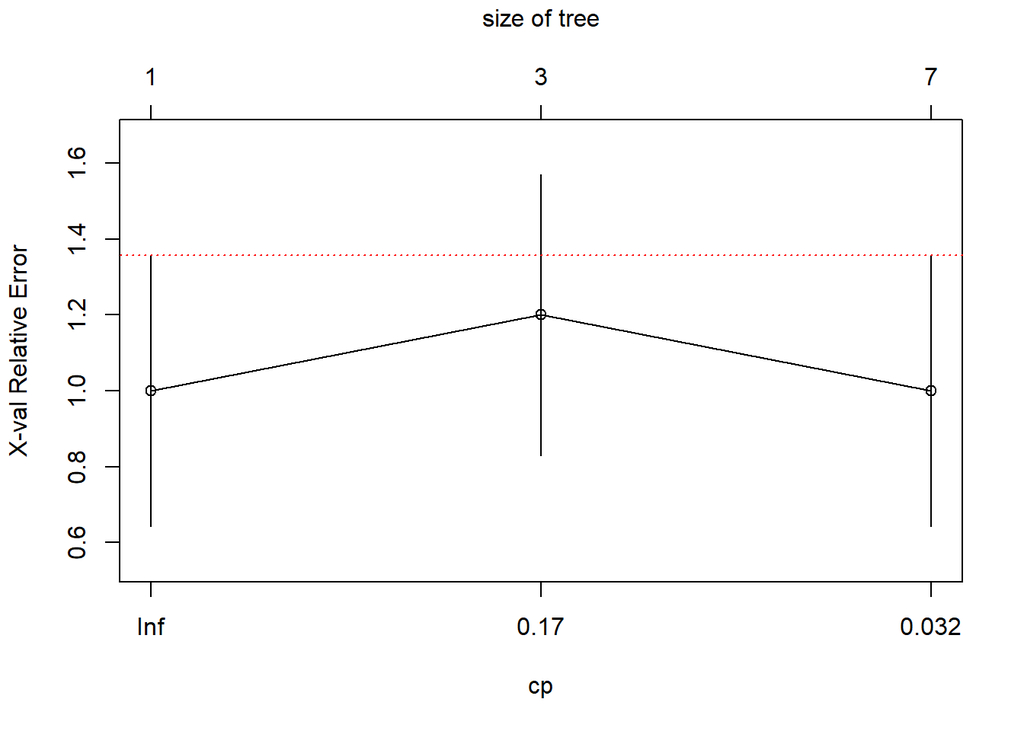

```r
plotcp(data_rpart, minline=TRUE, col="red")
```

If we use the logic above, we see that the **Best Pruned Tree** is the first tree, which only include the root node! So while it is true that the stopping point in rpart is CP = 0.01, the algorithm also does another level of pruning using xerror + xstd.

(Note below that we have removed the rpart.control() option and letting rpart chooses the **Best Pruned Tree**.)

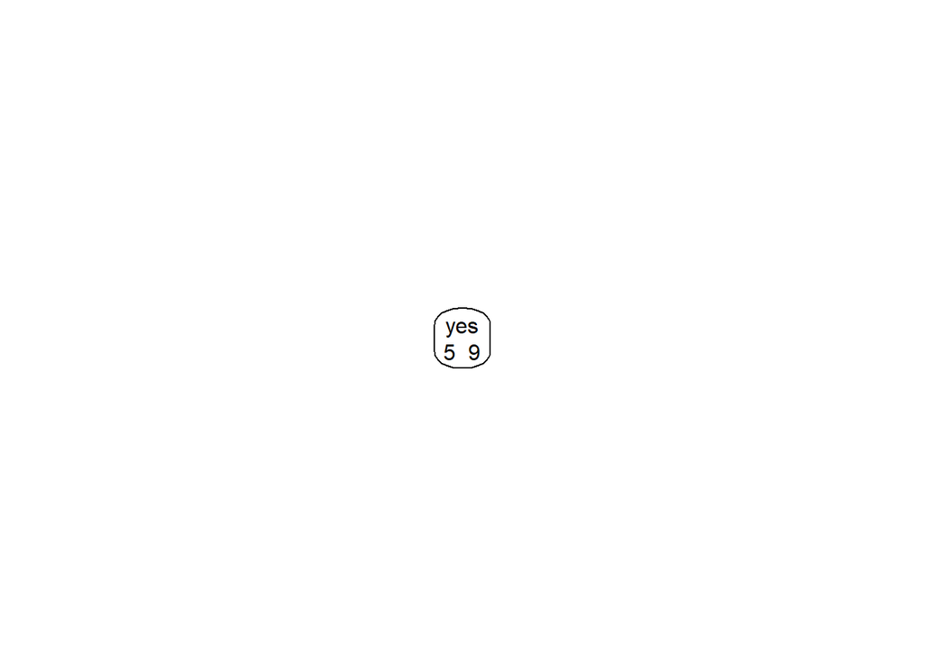

```r
data_rpart <- rpart(buys_computer ~ ., data=cust_data, method="class",
                    parms=list(split="gini"))

prp(data_rpart, type=1, extra=1, split.font=1, varlen = -10)
```

You should not be alarmed when you see such an output! Take some time to print the cp value table. If you need to build a fuller tree, use the control() option in rpart. You should also get familiar with the rpart.control() help file.

```r
#?rpart.control
```

## Returning to Our Opioid Prescriber Classification Problem

### A reminder about the variables

Here is the breakdown of the 331 variables:

Column 1: target variable; yes/no.

Column 331: dummy variable for male (i.e. gender).

Columns 241-291: state dummy variables.

Columns 292-330: medical speciality dummy variables.

Columns 2-240: number of prescriptions written for each non-opioid drug.

### Step #6: Partition the data (for supervised learning)

We will use an 80-20 split.

```r
prescribers<-read.csv("~/Dropbox/Spring_2018/BIA_6301_BCA/Week_3/prescribers.csv")

prescribers<-prescribers[,c(241,1:240,242:331)] #Rearranging the columns so that our target variable is first

table(prescribers$Opioid.Prescriber) #view the distribution of opioid vs. non-opioid prescribers
```

```
##
##    no   yes
## 10312 14688
```

```r
prescribers$Male <-ifelse(prescribers$Gender=="M",1,0) #if Male = 1; if Female=0.
prescribers<-prescribers[,-2] #We do not need the Gender variable anymore so delete it.

dim(prescribers)
```

```
## [1] 25000   331
```

```r
table(prescribers$Opioid.Prescriber)
```

```
##
##    no   yes
## 10312 14688
```

```r
library(caret)
set.seed(123) #ensures we get the same train/valid set.

trainIndex <- createDataPartition(prescribers$Opioid.Prescriber, p = .8,
                                  list = FALSE,
                                  times = 1)

prescribers_train <- prescribers[ trainIndex,]
prescribers_valid  <- prescribers[-trainIndex,]
```

### Steps 7, 8 & 9: Choose & implement the data mining techniques to be used. Interpret the results.

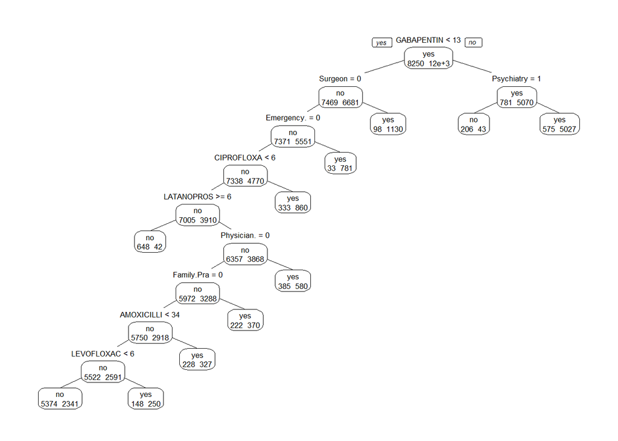

```r
library(rpart)

set.seed(123)
prescribers_rpart <- rpart(prescribers_train$Opioid.Prescriber~., method="class", parms = list(split="gini"), data=prescribers_train)

prp(prescribers_rpart, type=1, extra=1, split.font=1, varlen = -10)
```

#### Maybe something a bit fancier?

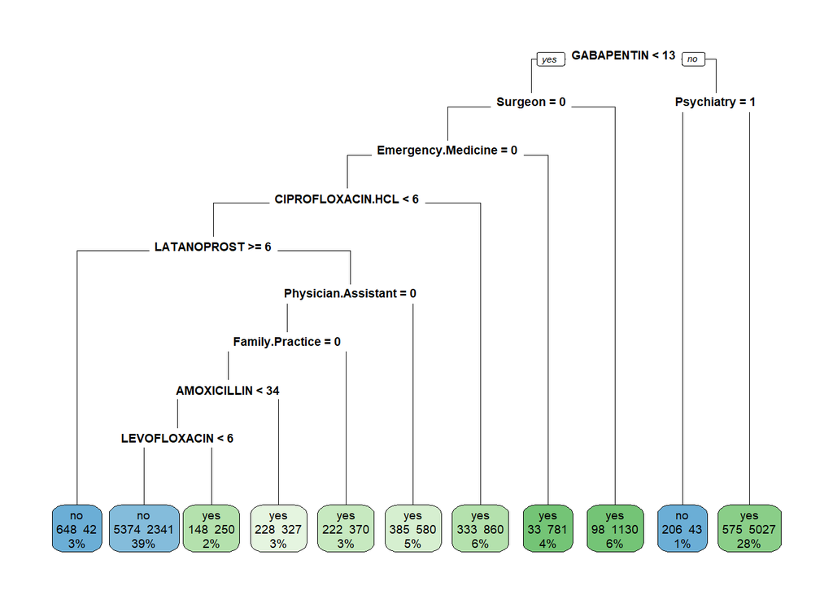

```r
rpart.plot(prescribers_rpart, type=0, extra=101)
```

The leaves show the opioid vs. non-opioid prescribers after the split at that node.

The blue indicates the majority in that subgroup is not frequent opioid prescribers (negatives). The green indicates the majority in that subgroup is frequent opioid prescribers (positives).

The label (yes or no) at each node indicates the label of the majority subgroup (for being a frequent opioid prescriber).

#### Vignette on using rpart.plot()

Check out this [vignette](http://www.milbo.org/rpart-plot/prp.pdf) on plotting rpart objects with rpart.plot(). A good resource for formatting your decision trees.

#### Let’s Look at the CP Table

rpart stops at 10 splits where cp = 0.01, which also corresponds to the best pruned tree. Remember that cp = 0.01 is the default stopping point.

```r
cptable<-printcp(prescribers_rpart)
```

```
##
## Classification tree:
## rpart(formula = prescribers_train$Opioid.Prescriber ~ ., data = prescribers_train,
##     method = "class", parms = list(split = "gini"))
##
## Variables actually used in tree construction:
##  [1] AMOXICILLIN         CIPROFLOXACIN.HCL   Emergency.Medicine
##  [4] Family.Practice     GABAPENTIN          LATANOPROST
##  [7] LEVOFLOXACIN        Physician.Assistant Psychiatry
## [10] Surgeon
##
## Root node error: 8250/20001 = 0.41248
##
## n= 20001
##
##         CP nsplit rel error  xerror      xstd
## 1 0.110303      0   1.00000 1.00000 0.0084389
## 2 0.090667      2   0.77939 0.77939 0.0080063
## 3 0.063879      3   0.68873 0.68873 0.0077308
## 4 0.019758      4   0.62485 0.62485 0.0074979
## 5 0.011818      5   0.60509 0.60679 0.0074257
## 6 0.010000     10   0.53915 0.54958 0.0071773
```

```r
cptable
```

```
##           CP nsplit rel error    xerror        xstd
## 1 0.11030303      0 1.0000000 1.0000000 0.008438876
## 2 0.09066667      2 0.7793939 0.7793939 0.008006295
## 3 0.06387879      3 0.6887273 0.6887273 0.007730848
## 4 0.01975758      4 0.6248485 0.6248485 0.007497893
## 5 0.01181818      5 0.6050909 0.6067879 0.007425725
## 6 0.01000000     10 0.5391515 0.5495758 0.007177348
```

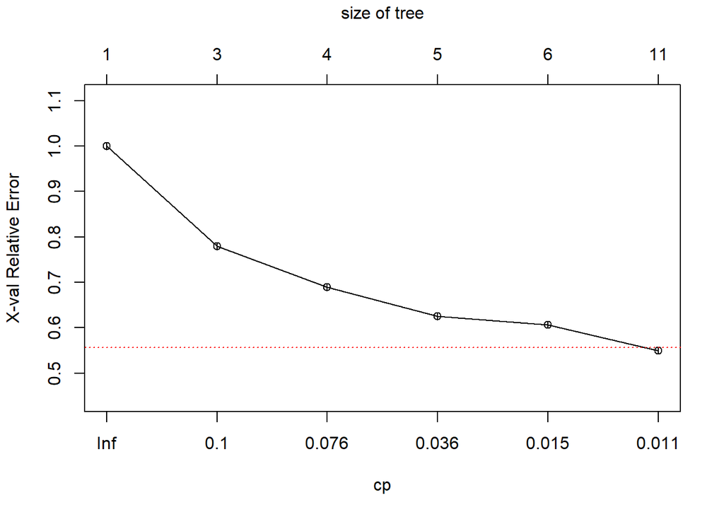

```r
plotcp(prescribers_rpart, minline=TRUE, col="red")
```

#### Elbow Plot Method

In the above cp plot, you can see there is an “elbow.” There exists another rule of thumb that says to look at tree size around the elbow. The idea is that beyond the “elbow”, we are decreasing the xerror but not by much. We can build a simpler tree without sacrificing too much xerror.

How about a tree with 5 splits?

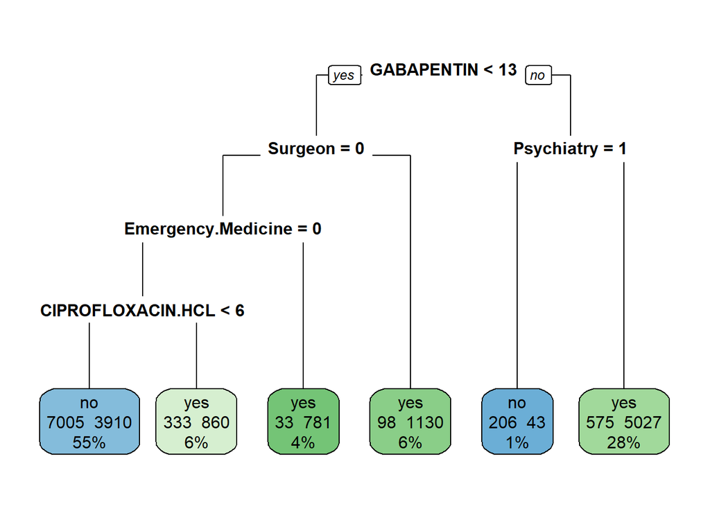

```r
set.seed(123)
prescribers_rpart_elbow <- rpart(prescribers_train$Opioid.Prescriber~., method="class", parms = list(split="gini"), control=rpart.control(maxdepth=5), data=prescribers_train)

rpart.plot(prescribers_rpart_elbow, type=0, extra=101)
```

#### Evaluating Model Performance

Note below that positives are “yes” (i.e. frequent opioid prescribers) and negatives are “no” (not frequent opioid prescribers).

#### Confusion Matrix

```r
#first we make predictions using the chosen decision tree model.
rpart_pred <- predict(prescribers_rpart_elbow, prescribers_valid, type="class")
#now we create a confusion matrix
result.matrix <- confusionMatrix(rpart_pred, prescribers_valid$Opioid.Prescriber, positive="yes")
print(result.matrix)
```

```
## Confusion Matrix and Statistics
##
##           Reference
## Prediction   no  yes
##        no  1796  942
##        yes  266 1995
##
##                Accuracy : 0.7584
##                  95% CI : (0.7462, 0.7702)
##     No Information Rate : 0.5875
##     P-Value [Acc > NIR] : < 2.2e-16
##
##                   Kappa : 0.5246
##  Mcnemar's Test P-Value : < 2.2e-16
##
##             Sensitivity : 0.6793
##             Specificity : 0.8710
##          Pos Pred Value : 0.8824
##          Neg Pred Value : 0.6560
##              Prevalence : 0.5875
##          Detection Rate : 0.3991
##    Detection Prevalence : 0.4523
##       Balanced Accuracy : 0.7751
##
##        'Positive' Class : yes
##
```

How does the decision tree model compare to the ones from Week #2?

| Model | Accuracy | Sensitivity | Specificity |
| --- | --- | --- | --- |
| knn = 9 | 77.68% | 75.28% | 81.09 |
| Naive Bayes | 62.57% | 40.99% | 93.31% |
| Logistic Regression | 81.94% | 82.50% | 81.13% |
| Decision Tree | 75.84% | 67.93% | 87.01% |

#### Kappa Statistic

$$Kappa = \frac{Pr(a) - Pr(e)}{1-Pr(e)}$$
Where,

Pr(a): proportion of actual agreement between the classifier and the true values

Pr(e): proportion of expected agreement between the classifier and the true values

Kappa “adjusts accuracy by accounting for the possibility of a correct prediction by **chance alone.** Kappa values range to a maximum number of 1, which indicates perfect agreement between the model’s predictions and the true values–a rare occurrence. Values less than one indicate imperfect agreement” (Lantz 2013, p. 303)

|  | Actual |  | Marginal_Frequency |
| --- | --- | --- | --- |
| Prediction | NO | YES |  |
| NO | 1796 | 942 | 2738 |
| YES | 266 | 1995 | 2261 |
| ——————- | ——– | ——– | ———————- |
| Marginal_Frequency | 2062 | 2937 |  |

**Ground truth**: 2062 NO; 2937 YES  
**Decision Tree Model**: 2738 NO; 2261 YES **TOTAL** = 5000

```r
Observed_Accuracy = (1796+1995)/5000
Expected_Accuracy_NO = (2738*2062)/5000
Expected_Accuracy_YES = (2261*2937)/5000
Expected_Accuracy_BOTH_CLASSES = (Expected_Accuracy_NO+Expected_Accuracy_YES)/5000
Kappa_Statistic = (Observed_Accuracy-Expected_Accuracy_BOTH_CLASSES)/(1-Expected_Accuracy_BOTH_CLASSES)

table<-cbind(Observed_Accuracy,Expected_Accuracy_NO,Expected_Accuracy_YES,Expected_Accuracy_BOTH_CLASSES, Kappa_Statistic)

table_t<-t(table)

colnames(table_t)<-c("value")

table_t #print table output
```

```
##                                       value
## Observed_Accuracy                 0.7582000
## Expected_Accuracy_NO           1129.1512000
## Expected_Accuracy_YES          1328.1114000
## Expected_Accuracy_BOTH_CLASSES    0.4914525
## Kappa_Statistic                   0.5245282
```

#### What’s a Good Kappa Value?

There is no one answer.

Landis & Koch (1977):

| Range | Strength |
| --- | --- |
| 0 - 0.2 | Poor |
| 0.21 - 0.4 | Fair |
| 0.41 - 0.6 | Moderate |
| 0.61 - 0.8 | Substantial |
| 0.81 - 1.0 | Almost perfect |

Fleiss (1981):

| Range | Strength |
| --- | --- |
| 0 - 0.4 | Poor |
| 0.41 - 0.75 | Fair to Good |
| 0.75 - 1 | Excellent |

Be careful! Kappa is not the best metric if accuracy is not what you are after. For more on kappa, here’s a good [post](https://stats.stackexchange.com/questions/82162/cohens-kappa-in-plain-english).

How does the Kappa statistic for the decision tree model compare to knn=9, Naive Bayes, and logistic regression?

| Model | Accuracy | Sensitivity | Specificity | Kappa |
| --- | --- | --- | --- | --- |
| knn = 9 | 77.68% | 75.28% | 81.09 | 0.5503 |
| Naive Bayes | 62.57% | 40.99% | 93.31% | 0.3076 |
| Logistic Regression | 81.94% | 82.50% | 81.13% | 0.6306 |
| Decision Tree | 75.84% | 67.93% | 87.01% | 0.5246 |

## A Note on Regression Trees

While not as popular as classification trees, regression trees are also used. The difference between the two types is that the latter makes prediction for a continuous numeric target variable. The process of creating splits and pruning remains the same. There are two differences:

1. The only difference is that each leaf node gives the average value of the training records at that node. Remember that the leaf node of the classification tree gives the majority class of the training records.
2. Instead of using a confusion matrix to gauge model performance, we would use mean error (ME), mean absolute error (MAE), root mean square error (RMSE), mean percent error (MPE), mean absolute percent error (MAPE). Revisit Week 1 class markdown file to review error metrics for numeric predictions.

```r
housing.df <- read.csv("~/Desktop/Week_4/WestRoxbury_clean.csv", header=TRUE)
names(housing.df)
```

```
##  [1] "TOTAL.VALUE" "TAX"         "LOT.SQFT"    "YR.BUILT"    "GROSS.AREA"
##  [6] "LIVING.AREA" "FLOORS"      "ROOMS"       "BEDROOMS"    "FULL.BATH"
## [11] "HALF.BATH"   "KITCHEN"     "FIREPLACE"   "REMODEL"
```

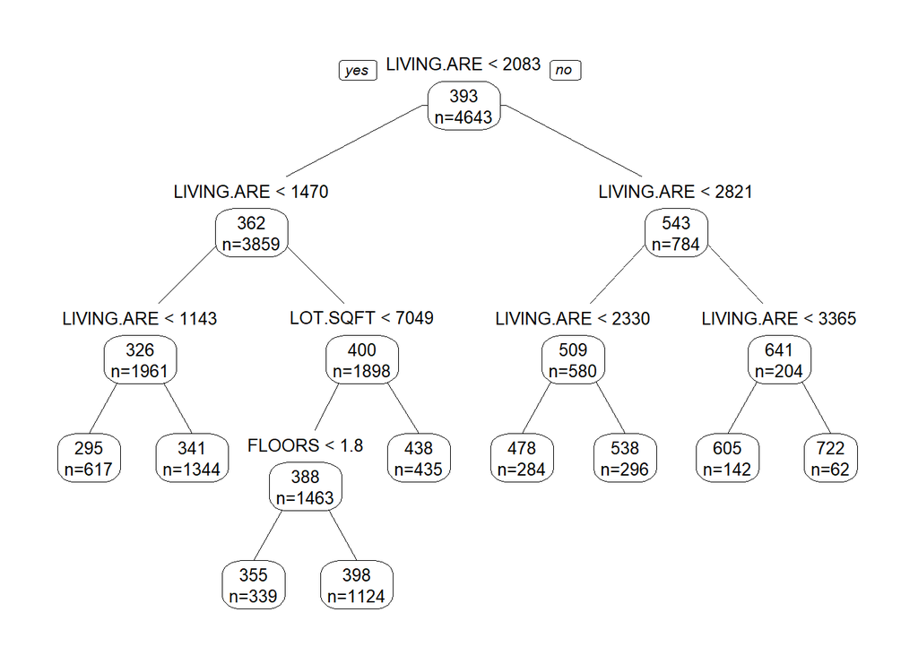

```r
housing.df$TAX <- NULL #remove tax column

#library(caret)
trainIndex <- createDataPartition(housing.df$TOTAL.VALUE, p = .8,
                                  list = FALSE,
                                  times = 1)

housing_train <- housing.df[ trainIndex,]
housing_valid  <- housing.df[-trainIndex,]

#library(rpart)
#library(rpart.plot)
data_rpart <- rpart(TOTAL.VALUE ~ ., data=housing_train, method="anova")
prp(data_rpart, type=1, extra=1, split.font=1, varlen = -10)
```

```r
cptable<-printcp(data_rpart)
```

```
##
## Regression tree:
## rpart(formula = TOTAL.VALUE ~ ., data = housing_train, method = "anova")
##
## Variables actually used in tree construction:
## [1] FLOORS      LIVING.AREA LOT.SQFT
##
## Root node error: 45984107/4643 = 9904
##
## n= 4643
##
##         CP nsplit rel error  xerror     xstd
## 1 0.462586      0   1.00000 1.00010 0.034169
## 2 0.112128      1   0.53741 0.55313 0.017851
## 3 0.057436      2   0.42529 0.43893 0.017023
## 4 0.018866      3   0.36785 0.39143 0.012856
## 5 0.017785      4   0.34898 0.36384 0.012493
## 6 0.012854      5   0.33120 0.34895 0.012175
## 7 0.011139      6   0.31835 0.33695 0.011903
## 8 0.010423      7   0.30721 0.32865 0.010857
## 9 0.010000      8   0.29678 0.32865 0.010857
```

```r
cptable
```

```
##           CP nsplit rel error    xerror       xstd
## 1 0.46258568      0 1.0000000 1.0000985 0.03416924
## 2 0.11212794      1 0.5374143 0.5531333 0.01785091
## 3 0.05743577      2 0.4252864 0.4389342 0.01702312
## 4 0.01886593      3 0.3678506 0.3914334 0.01285636
## 5 0.01778493      4 0.3489847 0.3638380 0.01249344
## 6 0.01285448      5 0.3311998 0.3489493 0.01217498
## 7 0.01113905      6 0.3183453 0.3369470 0.01190334
## 8 0.01042324      7 0.3072062 0.3286486 0.01085689
## 9 0.01000000      8 0.2967830 0.3286486 0.01085689
```

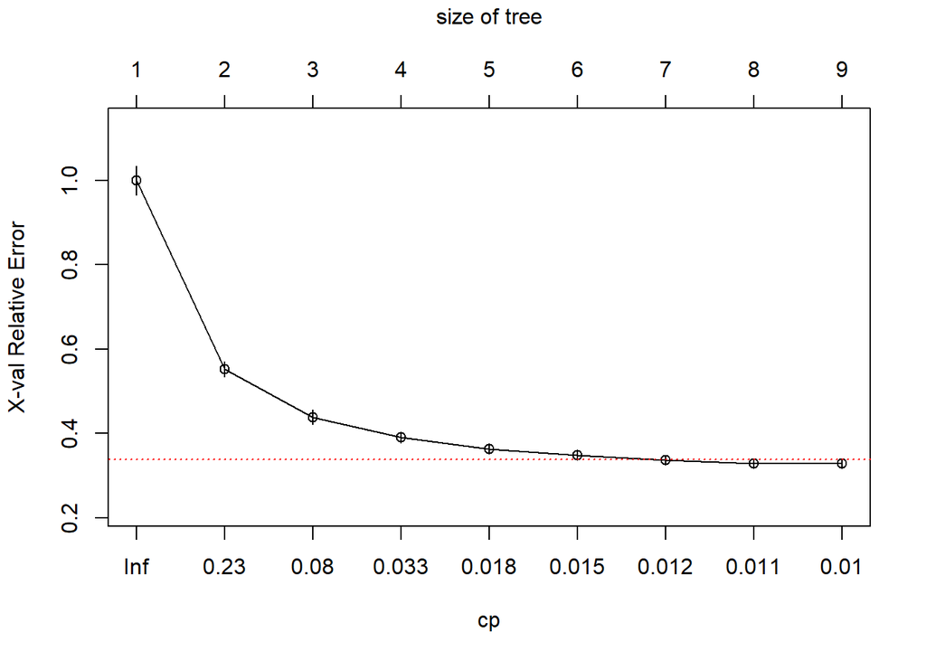

```r
plotcp(data_rpart, minline=TRUE, col="red") #elbow plot?
```

```r
pred_v <- predict(data_rpart, housing_valid)

library(forecast)
accuracy(pred_v, housing_valid$TOTAL.VALUE)
```

```
##                  ME     RMSE     MAE       MPE     MAPE
## Test set -0.3424484 53.53043 41.0666 -1.910164 10.86085
```

The RMSE of the stepwise regression from Week 1 was 42.58. The RMSE of the exhaustive search regression from Week 1 was 41.74. How does the regression tree compare?